# Age-dependent Branching Processes, with or without Immigration

Wribhu Banik, Aditya Ghosh and Shouvik Middey

Last updated: 17 January 2021

# Simulating Bellman-Harris branching processes

Age-dependent branching processes (without immigration) are also called Bellman-Harris processes. The following R codes can generate a realisation of this process till time $t,$ given the lifespan distribution (rlife) and the offspring distribution (roffsp). It returns the number of cells alive at time $t$ (end.time), the number of people born till time $t,$ and a list of birth times and death times, sorted in the order of depth first search of the vertices of the resulting tree.

```r
ADBP<-function(birth, N, end.time, alive = 0, rlife, roffsp, BD.list = NULL){
    if(N == 0) return(list(alive = alive, N = N, BD.list = BD.list))
    for(j in 1:N){
        death = birth + rlife(1)
        # print(paste("birth = ", birth, "death = ", death))
        BD.list = rbind(BD.list, c(birth, death))
        if(death < end.time){
            new = roffsp(1)
            Lst = ADBP(death, new, end.time, alive, rlife, roffsp, BD.list)
            N = N + Lst$N
            alive = Lst$alive
            BD.list = Lst$BD.list
        }
        else
            alive = alive + 1
    }
    return(list(alive = alive, N = N, BD.list = BD.list))
}
```

Here is an example: let us simulate a Bellman-Harris process where lifespans follow an Exponential distribution, and offspring distribution is a Poisson distribution.

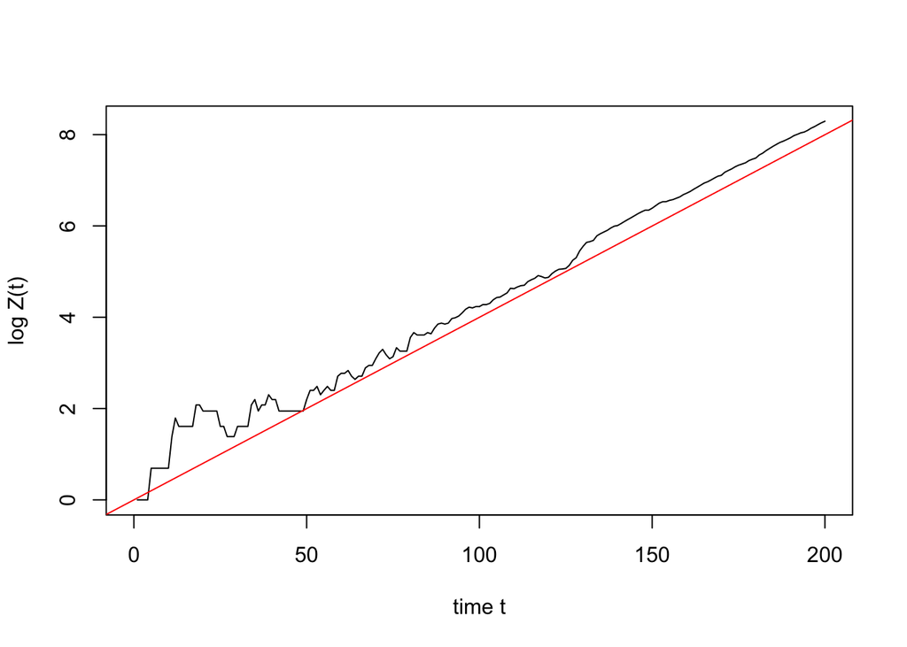

```r
set.seed(123)
Tmax = 200
mu = 5; m = 1.2
rlife = function(t) rexp(t, rate = 1/mu)
roffsp = function(n) rpois(n, m)

BHsiml = ADBP(birth = 0, N = 1, end.time = Tmax, alive = 0, rlife, roffsp, BD.list = NULL)
Snap <-function(t) return(sum(BHsiml$BD.list[,1]<t) - sum(BHsiml$BD.list[,2]<t))
Zt <- sapply(0:Tmax, Snap)

plot(0:Tmax, log(Zt), xlab = "time t", ylab = "log Z(t)", ty = "l")
abline(a = 0, b = (m-1)/mu, col = "red")
```

# Simulating inhomogeneous Poisson processes

The immigration process will be modelled by inhomogeneous Poisson processes (IPPs). The following R codes generate a realisation of this process till time of an IPP given the instantaneous rate function $r(\cdot).$

```r
IPP <- function(lambda, Tmax){
  f.v = NULL
  for(i in 1:1000)
    f.v = c(f.v, lambda(Tmax*(i/1000)))
  l.s = max(f.v)
  s = 0; t = NULL
  while(s < Tmax){
    w = -log(runif(1))/l.s
    s = s + w
    u = runif(1)
    if(u <= (lambda(s)/l.s))  t = c(t, s)
  }
  if(t[length(t)] <= Tmax)  return(t)
  return(t[-length(t)])
}
```

# Verifying the asymptotic behavior of the moments of Z(t)

Define $A(t)=\mathbb{E}Z(t)$ and $B(t) = \mathbb{E}Z(t)(Z(t)-1)$. The following R codes verify theorems 1 and 2 (in the report) regarding the asymptotic behavior of $A(t)$ and $B(t).$

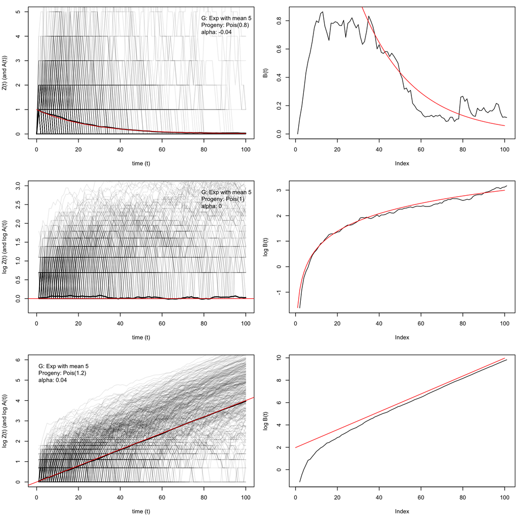

```r
ExpPois<-function(mu, m, Tmax){
    rlife = function(t) rexp(t, rate = 1/mu)
    roffsp = function(n) rpois(n, m)
    BHsiml = ADBP(birth = 0, N = 1, end.time = Tmax, alive = 0, rlife, roffsp)
    Z<-function(t) return(sum(BHsiml$BD.list[,1]<t) - sum(BHsiml$BD.list[,2]<t))
    return(sapply(0:Tmax, Z))
}


par(mfrow = c(3, 2), mar = c(5.1, 4.1, 1, 1))

set.seed(1)
# subcritical:
Zmat = NULL; Tmax = 100; lambda = 0.8; mu = 5
for(b in 1:1000)
        Zmat = rbind(Zmat, ExpPois(mu, lambda, Tmax))
alph = (lambda - 1)/mu
At <- apply(Zmat, 2, mean)
plot(0:Tmax, At, ylim = c(0, 5), xlab = "time (t)", ylab = "Z(t) (and A(t))", ty = "n")
Add = apply(Zmat, 1, function(t) lines(0:Tmax, t, col = rgb(0, 0, 0, 0.1)))
lines(0:Tmax, At, col = "black", lwd = 2)
lines(0:Tmax, exp(alph*(0:Tmax)), col = "red")
legend("topright", legend = paste("G: Exp with mean ",mu,"\nProgeny: Pois(",lambda,")\nalpha: ",alph, sep = ""), bty = 'n')
B1 = -lambda^2/(lambda-1)
Vt <- apply(Zmat, 2, var)
Bt <- Vt + At^2 - At
plot(Bt, ty = "l", ylab = "B(t)")
lines(0:Tmax, B1*exp(alph*(0:Tmax)), col = "red")

# critical:
Zmat = NULL; Tmax = 100; lambda = 1; mu = 5
for(b in 1:1000)
    Zmat = rbind(Zmat, ExpPois(mu,  lambda, Tmax))
At <- apply(Zmat, 2, mean)
alph = (lambda - 1)/mu
plot(0:Tmax, log(At), ylim = c(-0.25, 3), xlab = "time (t)", ylab = "log Z(t) (and log A(t))", ty = "n")
Add = apply(Zmat, 1, function(t) lines(0:Tmax, log(t), col = rgb(0, 0, 0, 0.1)))
lines(0:Tmax, log(At), col = "black", lwd = 2)
abline(a = 0, b = 0, col = "red")
legend("topright", legend = paste("G: Exp with mean ",mu,"\nProgeny: Pois(",lambda,")\nalpha: ",alph, sep = ""), bty = 'n')
Vt <- apply(Zmat, 2, var)
Bt <- Vt + At^2 - At
B2 = lambda^2/mu
plot(log(Bt), ty = "l", ylab = "log B(t)")
lines(0:Tmax, log(B2*(0:Tmax)), col = "red")

# supercritical:
Zmat = NULL; Tmax = 100; lambda = 1.2; mu = 5
for(b in 1:1000)
    Zmat = rbind(Zmat, ExpPois(mu,  lambda, Tmax))
alph = (lambda - 1)/mu
At <- apply(Zmat, 2, mean)
plot(0:Tmax, log(At), ylim = c(0, 6), xlab = "time (t)", ylab = "log Z(t) (and log A(t))", ty = "n")
Add = apply(Zmat, 1, function(t) lines(0:Tmax, log(t), col = rgb(0, 0, 0, 0.1)))
lines(0:Tmax, log(At), col = "black", lwd = 2)
abline(a = 0, b = alph, col = "red")
legend("topleft", legend = paste("G: Exp with mean ",mu,"\nProgeny: Pois(",lambda,")\nalpha: ",alph, sep = ""), bty = 'n')
Vt <- apply(Zmat, 2, var)
Bt <- Vt + At^2 - At
G2alpha = integrate(function(t) 1/mu * exp(-2*alph*t - t/mu), 0, Inf)$value
B3 = lambda^2 * G2alpha/(1 - lambda * G2alpha)
plot(log(Bt), ty = "l", ylab = "log B(t)")
lines(0:Tmax, 2*alph*(0:Tmax) + log(B3), col = "red")
```

# Simulating Age-dependent Branching Process with Immigration

```r
ADBPwI<-function(rate, rlife, roffsp, Tmax){
  Immigration.times = IPP(rate, Tmax)
  embBH = NULL
  for(t in Immigration.times)
    embBH = rbind(embBH, ADBP(birth = t, N = 1, end.time = Tmax, alive = 0, rlife, roffsp)$BD.list)
  return(embBH)
}
```

Following are some auxiliary functions that we will use.

```r
ExpUnif<-function(r, Tmax, n = 100){
    rlife <- function(t) rexp(t, rate = 1/2)
    roffsp <- function(t) sum(runif(t) > 0.2)
    Repl = NULL
    for(b in 1:n){
        ADBPwI.sim = ADBPwI(rate = r, rlife, roffsp, Tmax)
        Z<-function(t) return(sum(ADBPwI.sim[,1]<t) - sum(ADBPwI.sim[,2]<t))
        Repl = rbind(Repl, sapply(0:Tmax, Z))
    }
    return(Repl)
}

myplot<-function(Repl, Tmax){
    apply(Repl, 1, function(t) lines(0:Tmax, t, col = rgb(0, 0, 0, 0.1)))
    Mt <- apply(Repl, 2, mean)
    Sdt <- apply(Repl, 2, sd)
    df <- data.frame(x = 0:Tmax, M = Mt, L = Mt - Sdt, U = Mt + Sdt)
    lines(df$x, df$M)
    polygon(c(df$x, rev(df$x)), c(df$L, rev(df$U)), col = rgb(1, 0, 0, 0.1), border = F)
    lines(df$x, df$M, lwd = 2)
    lines(df$x, df$U, col = "red", lty = 2)
    lines(df$x, df$L, col = "red", lty = 2)
    #plot(0:Tmax, Sdt/Mt, ty = "l", xlab = "time t", ylab = "Cv(t)")
}
```

Let us now see how Z(t) behaves in absence (left panel) or presence (right panel) of time-homogeneity of the immigration process.

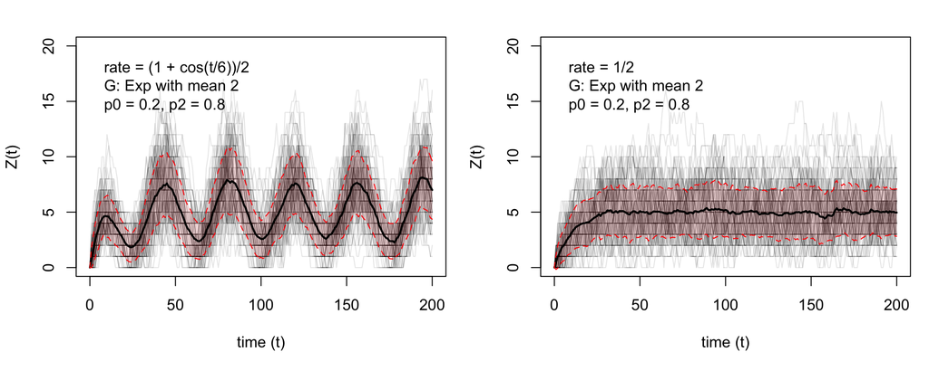

```r
set.seed(123)
Tmax = 200
par(mfrow = c(1, 2), mar = c(5.1, 4.1, 2, 1))
r <- function(t) (1 + cos(t/6))/2
plot(NULL, xlab = "time (t)", ylab = "Z(t)", xlim = c(0, 200), ylim = c(0, 20))
legend("topleft", legend = paste("rate = (1 + cos(t/6))/2\nG: Exp with mean 2\np0 = 0.2, p2 = 0.8"), bty = 'n')
myplot(ExpUnif(r, Tmax), Tmax)

r <- function(t) 1/2
plot(NULL, xlab = "time (t)", ylab = "Z(t)", xlim = c(0, 200), ylim = c(0, 20))
legend("topleft", legend = paste("rate = 1/2\nG: Exp with mean 2\np0 = 0.2, p2 = 0.8"), bty = 'n')
myplot(ExpUnif(r, Tmax), Tmax)
```

Lets see how the sample coefficients of variation change with respect to time, for the above two examples.

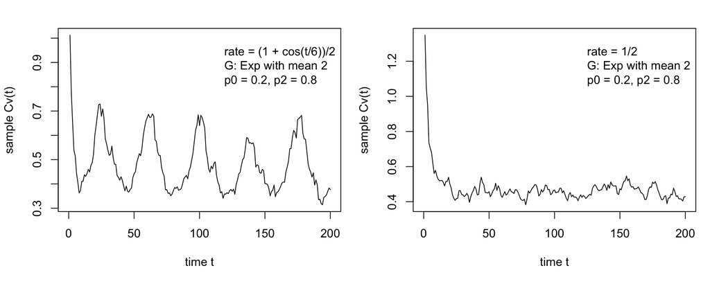

```r
set.seed(123)
Tmax = 200
par(mfrow = c(1, 2), mar = c(5.1, 4.1, 2, 1))

r <- function(t) (1 + cos(t/6))/2
Repl <- ExpUnif(r, Tmax)
Mt <- apply(Repl, 2, mean)
Sdt <- apply(Repl, 2, sd)
plot(0:Tmax, Sdt/Mt, ty = "l", xlab = "time t", ylab = "sample Cv(t)")
legend("topright", legend = paste("rate = (1 + cos(t/6))/2\nG: Exp with mean 2\np0 = 0.2, p2 = 0.8"), bty = 'n')

r <- function(t) 1/2
Repl <- ExpUnif(r, Tmax)
Mt <- apply(Repl, 2, mean)
Sdt <- apply(Repl, 2, sd)
plot(0:Tmax, Sdt/Mt, ty = "l", xlab = "time t", ylab = "sample Cv(t)")
legend("topright", legend = paste("rate = 1/2\nG: Exp with mean 2\np0 = 0.2, p2 = 0.8"), bty = 'n')
```

# Criticisms against the test proposed by Hyrien et al. for testing homogeneity

For simulation purpose we sample from the observed process, and pretend that the process was actually observed at only those time points. We use the following two examples for supporting the criticisms.

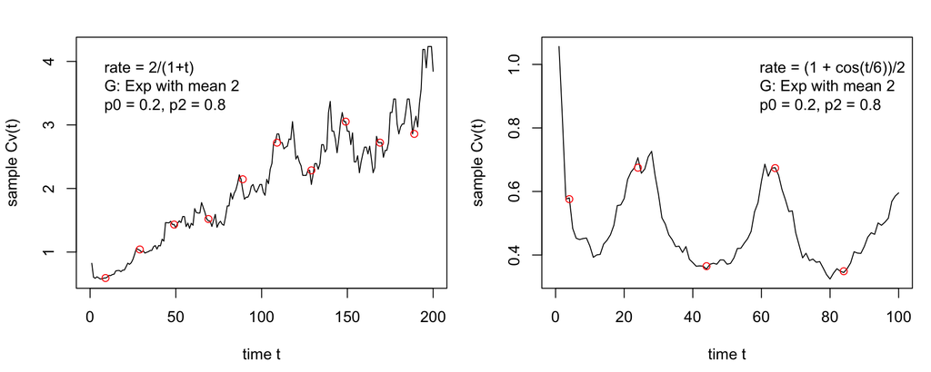

```r
set.seed(123)
r <- function(t) 2/(1+t)
Tmax <- 200
n <- 100
Repl <- ExpUnif(r, Tmax, n)
Mt <- apply(Repl, 2, mean)
Sdt <- apply(Repl, 2, sd)
par(mfrow = c(1, 2), mar = c(4.5, 4.1, 2, 1))

plot(0:Tmax, Sdt/Mt, ty = "l", xlab = "time t", ylab = "sample Cv(t)")
legend("topleft", legend = paste("rate = 2/(1+t)\nG: Exp with mean 2\np0 = 0.2, p2 = 0.8"), bty = 'n')

time.pts = seq(sample(0:(Tmax/20), 1), Tmax, by = 20)
m = length(time.pts)
Data = Repl[, time.pts]
# plot(NULL, xlim = range(time.pts), ylim = range(Data))
# apply(Data, 1, function(t) lines(time.pts, t))
Cvt <- apply(Data, 2, sd)/apply(Data, 2, mean)
points(Cvt ~ time.pts, col = "red")

set.seed(123)
r <- function(t) (1 + cos(t/6))/2
Tmax <- 100
n <- 100
Repl <- ExpUnif(r, Tmax, n)
Mt <- apply(Repl, 2, mean)
Sdt <- apply(Repl, 2, sd)

plot(0:Tmax, Sdt/Mt, ty = "l", xlab = "time t", ylab = "sample Cv(t)")
legend("topright", legend = paste("rate = (1 + cos(t/6))/2\nG: Exp with mean 2\np0 = 0.2, p2 = 0.8"), bty = 'n')

time.pts = seq(sample(0:(Tmax/20), 1), Tmax, by = 20)
m = length(time.pts)
Data = Repl[, time.pts]
# plot(NULL, xlim = range(time.pts), ylim = range(Data))
# apply(Data, 1, function(t) lines(time.pts, t))
Cvt <- apply(Data, 2, sd)/apply(Data, 2, mean)
points(Cvt ~ time.pts, col = "red")
```

## Criticism 1

```r
set.seed(123)
r <- function(t) 2 * 1/(1+t)
Tmax = 200
time.pts = seq(sample(0:(Tmax/20), 1), Tmax, by = 20)
m = length(time.pts)
n = 100
pval = NULL; pval2 = NULL
for(rp in 1:100){
Data = ExpUnif(r, Tmax, n)[, time.pts]
Cvt <- apply(Data, 2, sd)/apply(Data, 2, mean)
fit = lm(Cvt ~ time.pts + I(time.pts^2))
fit2 = lm(log(Cvt) ~ time.pts + I(time.pts^2))
B = 2000
bCvt = NULL
for(b in 1:B){
    bData = Data[, sample(1:m, m, replace = TRUE)]
    bCvt = rbind(bCvt, apply(bData, 2, sd)/apply(bData, 2, mean))
    bCvt2 = rbind(bCvt, log(apply(bData, 2, sd)/apply(bData, 2, mean)))
}
bMean = apply(bCvt, 1, mean)
Sig = n/(B - 1) * t(bCvt - bMean) %*% (bCvt - bMean)
X = model.matrix(fit)
Y = solve(t(X) %*% (X))
V = Y %*% t(X) %*% Sig %*% X %*% Y
p = length(fit$coef)
theta2p = fit$coef[-1]
test.stat = n * theta2p %*% solve(V[2:p, 2:p]) %*% theta2p
pval = c(pval, pchisq(test.stat, p-1, lower.tail = FALSE))


bMean2 = apply(bCvt2, 1, mean)
Sig2 = n/(B - 1) * t(bCvt2 - bMean2) %*% (bCvt2 - bMean2)
X2 = model.matrix(fit2)
Y2 = solve(t(X2) %*% (X2))
V2 = Y2 %*% t(X2) %*% Sig2 %*% X2 %*% Y2
p2 = length(fit2$coef)
theta2p2 = fit2$coef[-1]
test.stat2 = n * theta2p2 %*% solve(V2[2:p, 2:p]) %*% theta2p2
pval2 = c(pval2, pchisq(test.stat2, p-1, lower.tail = FALSE))
}

mean(pval)
```

```
## [1] 0.0116783
```

```r
sum(pval < 0.05)
```

```
## [1] 100
```

```r
mean(pval2)
```

```
## [1] 0.2100589
```

```r
sum(pval2 < 0.05)
```

```
## [1] 0
```

## Criticism 2

This is an example of an inhomogeneous case where time points are not large. Again we will see that the test can be less effective (for a possibly poor choice of the predictors in the model).

```r
set.seed(123)
r <- function(t) (1 + cos(t/6))/2
Tmax = 100
time.pts = seq(sample(0:(Tmax/20), 1), Tmax, by = 20)
m = length(time.pts)
n = 100
pval = NULL; pval2 = NULL

for(rp in 1:100){
Data = ExpUnif(r, Tmax, n)[, time.pts]
Cvt <- apply(Data, 2, sd)/apply(Data, 2, mean)
fit = lm(Cvt ~ time.pts + I(time.pts^2))
fit2 = lm(log(Cvt) ~ time.pts + I(time.pts^2))
B = 2000
bCvt = NULL
for(b in 1:B){
    bData = Data[, sample(1:m, m, replace = TRUE)]
    bCvt = rbind(bCvt, apply(bData, 2, sd)/apply(bData, 2, mean))
    bCvt2 = rbind(bCvt, log(apply(bData, 2, sd)/apply(bData, 2, mean)))
}
bMean = apply(bCvt, 1, mean)
Sig = n/(B - 1) * t(bCvt - bMean) %*% (bCvt - bMean)
X = model.matrix(fit)
Y = solve(t(X) %*% (X))
V = Y %*% t(X) %*% Sig %*% X %*% Y
p = length(fit$coef)
theta2p = fit$coef[-1]
test.stat = n * theta2p %*% solve(V[2:p, 2:p]) %*% theta2p
pval = c(pval, pchisq(test.stat, p-1, lower.tail = FALSE))


bMean2 = apply(bCvt2, 1, mean)
Sig2 = n/(B - 1) * t(bCvt2 - bMean2) %*% (bCvt2 - bMean2)
X2 = model.matrix(fit2)
Y2 = solve(t(X2) %*% (X2))
V2 = Y2 %*% t(X2) %*% Sig2 %*% X2 %*% Y2
p2 = length(fit2$coef)
theta2p2 = fit2$coef[-1]
test.stat2 = n * theta2p2 %*% solve(V2[2:p, 2:p]) %*% theta2p2
pval2 = c(pval2, pchisq(test.stat2, p-1, lower.tail = FALSE))
}

mean(pval)
```

```
## [1] 0.1570384
```

```r
sum(pval < 0.05)
```

```
## [1] 0
```

```r
mean(pval2)
```

```
## [1] 0.01573551
```

```r
sum(pval2 < 0.05)
```

```
## [1] 100
```

# Future scopes

- Can we make the test suitable also for the inhomogeneous cases where $C_v(t)$ converges to a constant?
- Can we make the test better by suitably choosing the predictors in the model?
- Can we have a more powerful test?
- Can we have an approach which tackles the absence of homogeneity in more generality?
- When homogeneity is rejected, how can we estimate the immigration rate?
- How to test a pre-specified form of the immigration rate?